# Reproducible Pitch: Time Series Forecasting Application

3/3/2021

## Introduction

This application allows you to forecast the ‘rgdpo’ (output-side real GDP at chained PPPs in million 2017 USD) variable from the Penn World Table 10.0 for 6 Latin American countries for the period 2020-2029. You may select a country and a unique combination of time series models to evaluate which model is the best: i.e., the one with the lowest error in the ‘test set’.

The Shiny application address is: https://carloschunga.shinyapps.io/pwt10_forecast/.

The first plot shows forecasts for all selected models from the test set onwards; below, you will find the RMSE and MAPE to measure the error in the test set, and the best model according to the MAPE. Finally, the last boxes show the forecast with its prediction intervals according to the best model.

## Example with Chile: Forecast

Let’s see an example by selecting “Chile” and all 4 time series models, where ARIMA is the best model:

```r
ts_best_forecast("Chile", c("holt", "ets", "arima", "tbats"))
```

```
     Point Forecast    Lo 80    Hi 80    Lo 95    Hi 95
2020       447264.8 436675.6 457854.0 431070.1 463459.6
2021       457734.9 436432.3 479037.6 425155.3 490314.6
2022       468205.1 438920.4 497489.7 423418.0 512992.1
2023       478675.2 442224.2 515126.2 422928.1 534422.2
2024       489145.3 445875.8 532414.8 422970.4 555320.2
2025       499615.4 449680.7 549550.2 423246.8 575984.0
2026       510085.5 453538.5 566632.6 423604.3 596566.8
2027       520555.7 457391.7 583719.6 423954.7 617156.6
2028       531025.8 461204.3 600847.2 424243.1 637808.4
2029       541495.9 464953.2 618038.6 424434.0 658557.8
```

## Example with Chile: Best Model (ARIMA) Plot

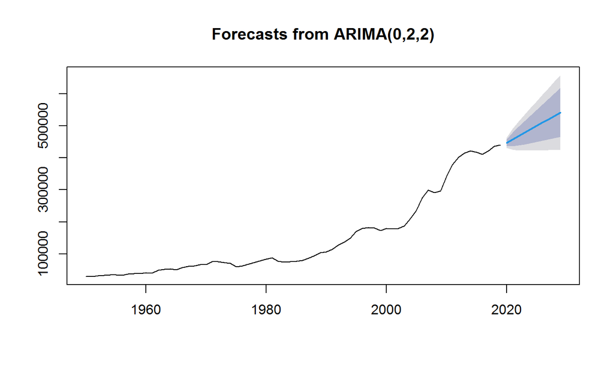

```r
ts_best_plot("Chile", c("holt", "ets", "arima", "tbats"))
```

## Conclusion

Due to the constraint on the number of slides, I cannot show the full code in this pitch; instead, I show the results of some custom functions I constructed. For the full code and more information you can access my repository on GitHub: https://github.com/carloschunga/pwt10_forecast.

Thank you for your attention!